# Homework #7

Craig Orman

3/9/2022

Link to the [Github Project](https://github.com/ArgentCode/DS202-HW7)

## Chick weights

#### Due: 3/21/2022 before 11:59pm. Submit in Canvas (file upload).

The `ChickWeight` data set is part of the base package `datasets`. See `?ChickWeight` for details on the data. For all of the questions use `dplyr` functions whenever possible.

1. Download the RMarkdown file with these homework instructions to use as a template for your work. Make sure to replace “Your Name” in the YAML with your name.

```r
library(tidyverse)
library(reshape2)
library(dplyr)
chickweight = ChickWeight
```

## Question 2

2. Get a frequency breakdown of the number of chicks, their average weight and the standard deviation of the weights in each of the diets at the start of the study.

```r
temp =
  filter(chickweight, Time == 0) %>%
  group_by(Diet) %>%
  summarise(across(c("weight"), list(mean = mean, sd = sd)))
temp2 =
  filter(chickweight, Time == 0) %>%
  group_by(Diet) %>%
  count()
temp$count = temp2$n
temp
```

```
## # A tibble: 4 x 4
##   Diet  weight_mean weight_sd count
##   <fct>       <dbl>     <dbl> <int>
## 1 1            41.4     0.995    20
## 2 2            40.7     1.49     10
## 3 3            40.8     1.03     10
## 4 4            41       1.05     10
```

### 2 answer

The chicks in diet 1 seemed to, on average, start the heaviest, and have the smallest standard deviation at 0.99. The chicks in diet 2 have the smallest average weight and the highest standard deviation at 40.7 weight and 1.49 standard deviation. All diets have 10 chicks except group 1 which has 20.

## Question 3

3. construct a ggplot that shows average weights by diet with an interval (shown as a line) of +- the standard deviation around the averages.

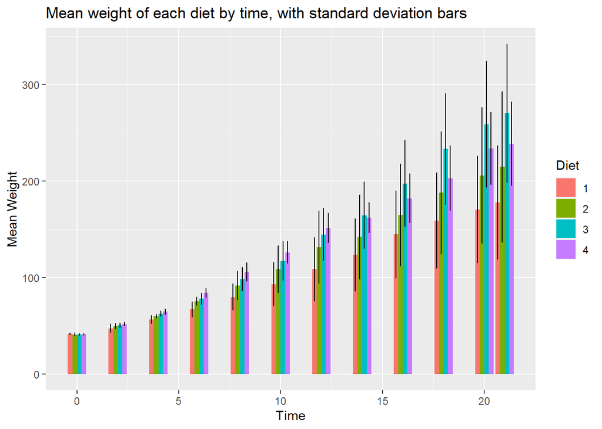

```r
chickweight %>% group_by(Diet, Time) %>% summarise(
  m.weight = mean(weight, na.rm=TRUE),
  sd.weight = sd(weight, na.rm=TRUE)) %>%
  ggplot(aes(x=Time, fill=Diet)) +
  geom_bar(aes(weight=m.weight), position=position_dodge()) +
  geom_errorbar(aes(ymin=m.weight-sd.weight, ymax=m.weight+sd.weight), colour="black", width=.1, position=position_dodge(.9)) +
  ylab("Mean Weight") +
  ggtitle("Mean weight of each diet by time, with standard deviation bars")
```

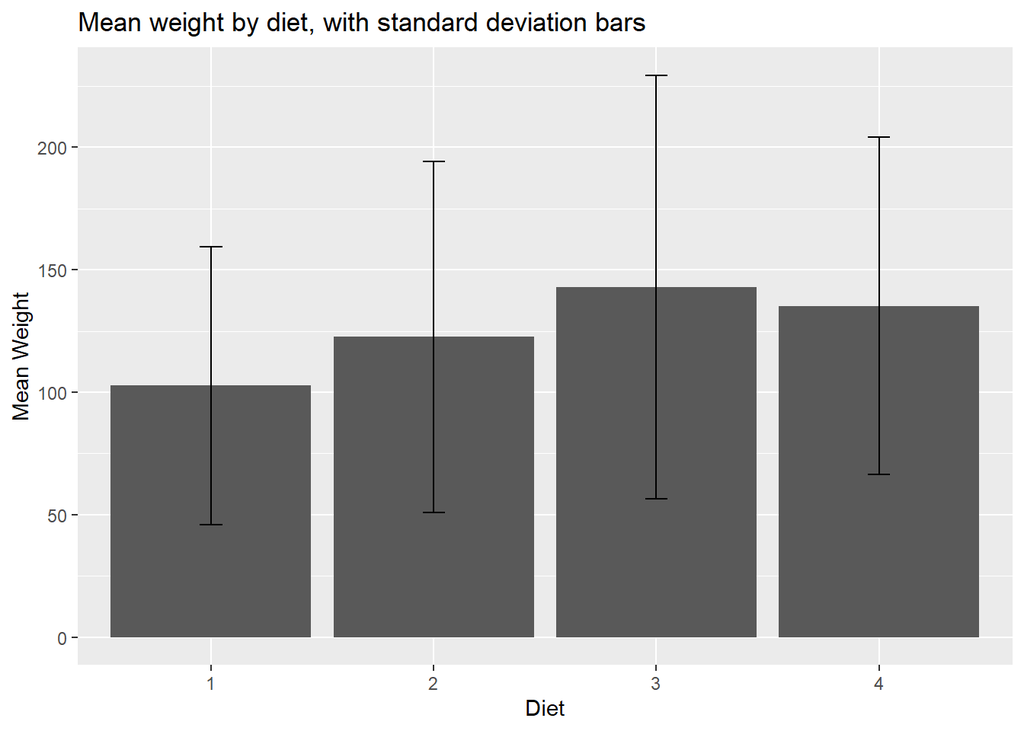

```r
chickweight %>% group_by(Diet) %>% summarise(
  m.weight = mean(weight, na.rm=TRUE),
  sd.weight = sd(weight, na.rm=TRUE)) %>%
  ggplot(aes(x=Diet)) +
  geom_bar(aes(weight=m.weight), position=position_dodge()) +
  geom_errorbar(aes(ymin=m.weight-sd.weight, ymax=m.weight+sd.weight), colour="black", width=.1, position=position_dodge(.9)) +
  ylab("Mean Weight") +
  ggtitle("Mean weight by diet, with standard deviation bars")
```

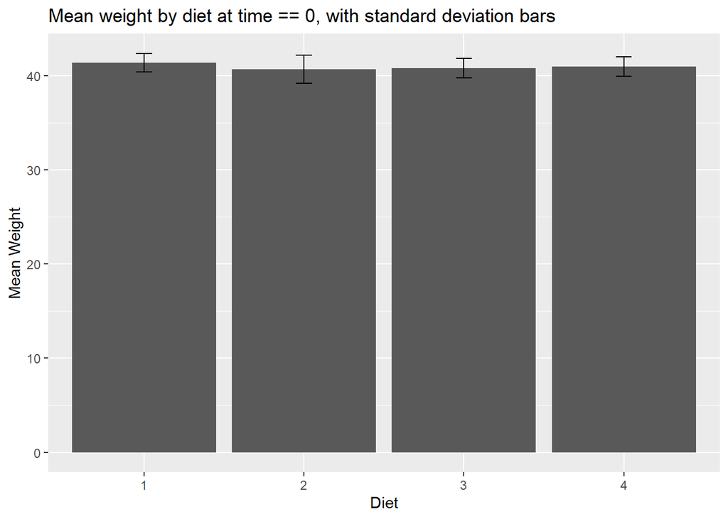

```r
filter(chickweight, Time == 0) %>% group_by(Diet) %>% summarise(
  m.weight = mean(weight, na.rm=TRUE),
  sd.weight = sd(weight, na.rm=TRUE)) %>%
  ggplot(aes(x=Diet)) +
  geom_bar(aes(weight=m.weight), position=position_dodge()) +
  geom_errorbar(aes(ymin=m.weight-sd.weight, ymax=m.weight+sd.weight), colour="black", width=.1, position=position_dodge(.9)) +
  ylab("Mean Weight") +
  ggtitle("Mean weight by diet at time == 0, with standard deviation bars")
```

### 3 Answer

This question confused me admittedly so I made 3 graphs for each of my interpretations of the question. Graph 1: This shows the mean weight with standard deviation bars for each of the diets at each time intervals, we see that as time progresses, the standard deviations get rather large Graph 2: This is the graph I think the question intended to be answered with, but you can’t really infer anything off of it. The graph uses a mix of all the times. Graph 3: This is the graph at time 0, so it shows they are all quite similar, with Diet 1 having the highest mean.

## Question 4

4. Each chick should have twelve weight measurements. Use the dplyr package to identify how many chicks have a complete set of weight measurements and how many measurements there are in the incomplete cases. Extract a subset of the data for all chicks with complete information and name the data set `complete`. (Hint: you might want to use mutate to introduce a helper variable consisting of the number of observations)

### 4 answer

There are 45 chicks with full data sets, and 5 with missing data. Of the 5 chicks with missing data we are missing 22 individual time measurements. In each of the bad data sets, it is a cut off rather than a gap. This implies the chick was removed from the study at that point for whatever reason.

```r
chickweight.long = chickweight %>% spread(key=Time, value=weight)
chickweight.long$na_count = apply(is.na(chickweight.long), 1, sum)

complete = chickweight.long %>% filter(na_count == 0)
complete = complete %>% select(-na_count)
badData = chickweight.long %>% filter(na_count > 0)


complete = complete %>% gather(key = time, value = weight, 3:14)
```

## Question 5

5. In the complete data set introduce a new variable that measures the current weight difference compared to day 0. Name this variable `weightgain`.

```r
complete = complete %>%
  group_by(Chick) %>%
  mutate(Chick = Chick,
         Diet = Diet,
         time = time,
         weight = weight,
         weightgain = weight - first(weight))
```

### 5 answer

No matter how I went about it I kept ending up with weird data due to using the group by function to find the differences. This is the strange solution I found.

### Question 6

6. Use ggplot2 to create side-by-side boxplots of `weightgain` by `Diet` for day 21. Describe the relationship in 2-3 sentences. Change the order of the categories in the Diet variable such that the boxplots are ordered by median `weightgain`.

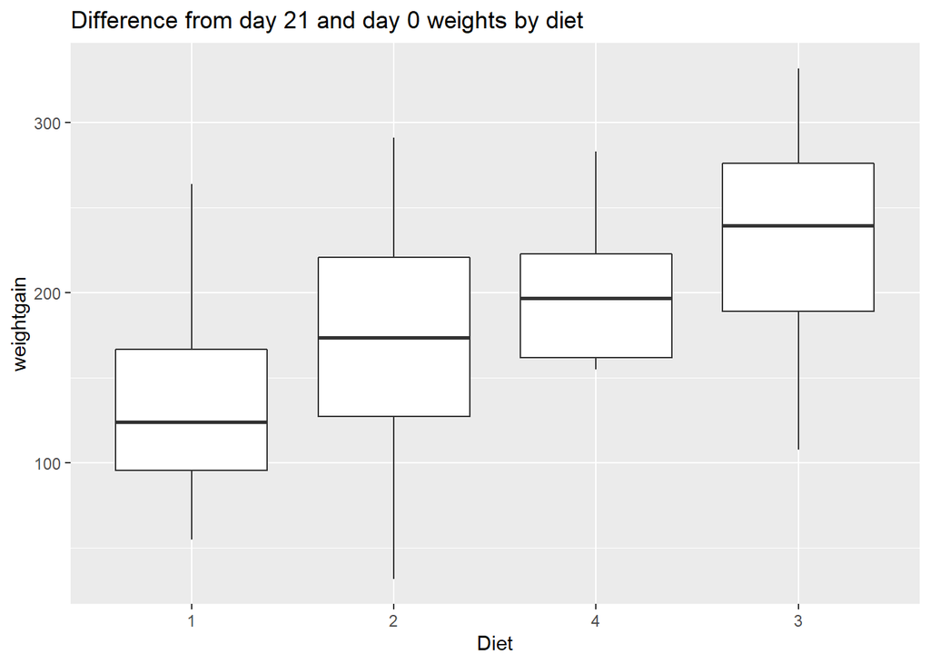

```r
complete %>% filter(time == 21) %>%
  ggplot(aes(x=fct_reorder(Diet, weightgain, median), y=weightgain)) + geom_boxplot() +
  xlab("Diet") +
  ggtitle("Difference from day 21 and day 0 weights by diet")
```

### 6 answer

Diet 1 had the lowest median weightgain, while diet 3 had the highest. The IQR and lines surrounding diet 4 are very small in comparison to the others. Diet 2 has the widest spread of data, and some of the lowest scores.

Note: your submission is supposed to be fully reproducible, i.e. the TA and I will ‘knit’ your submission in RStudio.

For the submission: submit your solution in an R Markdown file and (just for insurance) submit the corresponding html (or Word) file with it.